# Ecological Site Group Description: Semiarid Warm Loamy Uplands

Anna Knight and Travis Nauman

2/28/2022

*NOTE: This correspondence is intended for communication of project progress among funders and collaborators only. This report is provisional and preliminary, and the information is subject to change without notification. The findings have not been peer-reviewed nor Bureau approved.*

# General information

## Associated ecological site concepts

This ecological site group includes a variety of upland ecological sites that have deeper sandy soils without significant rock content. The group was defined by placing ecological sites into groups by separating soils, climate, and geomorphic features to best differentiate reference vegetation production values and documented ecological states as documented ny Nauman et al., (In Review).

This ecological site group includes 15 ecological sites. These sites were correlated to the group based on average soil, climate and geomorphic properties of the soil components linked to each ecological site.

Table 1: Ecological Sites associated with this ESG

| ESD Code | ESD Name |
| --- | --- |
| F035XF628AZ | Sandy Loam Upland (JUOS, PIED) 13-17” p.z. |
| R034AY150WY | Sandy (Green River - Great Divide Basins) |
| R034AY166WY | Shallow Sandy (Green River - Great Divide Basins) |
| R034BY212UT | Semidesert Loam (Wyoming Big Sagebrush) |
| R034BY216UT | Semidesert Sandy Loam (Fourwing Saltbush) |
| R035XA113NM | Sandy |
| R035XC313AZ | Loamy Upland 10-14” p.z. |
| R035XC334AZ | Sandy Loam Upland 10-14” p.z. Calcareous |
| R035XF606AZ | Sandy Loam Upland 13-17” p.z. |
| R035XG127NM | Savanna |
| R035XH002NM | Mountain Grassland |
| R035XH807AZ | Loamy Upland 17-25” p.z. |
| R035XY206UT | Semidesert Gravelly Loam (Utah Juniper-Pinyon) |
| R035XY306UT | Upland Loam (Basin Big Sagebrush) |
| R035XY308UT | Upland Loam (Mountain Big Sagebrush) |

Table 2: Dominant plant species

| Item | Description |
| --- | --- |
| Trees | oak , twoneedle pinyon, juniper , ponderosa pine , Utah juniper |
| Shrubs | basin big sagebrush , mountain big sagebrush, Wyoming big sagebrush , blackbrush , skunkbush sumac |
| Grasses | Arizona fescue , New Mexico muhly , mountain muhly , blue grama , Kentucky bluegrass |
| Forbs | Anderson’s larkspur, scarlet gilia , rock goldenrod , lupine , tapertip hawksbeard |

# Physiographic features

These sites occur on upland positions with mostly gentle slopes on a variety of landforms (n=32). Some areas can have steeper slopes, but these are not typical of the group.

Table 3: Representative physiographic features

[output not shown]

# Climatic features

Climate is generally semiarid and warm with aridity index (precipitation / potential evapotranspiration) values averaging 0.18 and ranging from 0.14 to 0.25. The average maximum temperatures (Celsius) of the hottest month range from 25.14 to 32.75, and minimum temperatures of the coldest month range from -17.52 to -8.00. Warm season (June to September) precipitation makes up 40% of total precipitation on average, but can range from 31% to 48%.

Table 4: Representative climatic features (min, mean, max)

| Item | Description |
| --- | --- |
| Frost Free Period (days) | 50, 107, 168 |
| Mean Annual Precipitation (in) | 8.0, 8.8, 12.0 |

# Water features

These sites neither benefit significantly from run-in moisture nor experience excessive loss of moisture from runoff.

# Soil features

Table 5: Representative soil features

| Item | Description |
| --- | --- |
| Parent Material | alluvium and eolian sediments |
| Surface Texture (0-30cm) | sandy loam, loam |
| Subsurface Texture (>30cm) | sandy loam , loam , sandy clay loam |
| Drainage | Well drained , Somewhat excessively drained, Excessively drained |
| Soil Depth | 67-201 cm |
| Surface Rock Content %vol (0-30cm) | 0-25% |
| Subsurface Rock Content %vol (>30cm) | 0-29% |
| Surface Electrical Conductivity (0-30cm) | 0-1.2 dS/m |
| Subsurface Electrical Conductivity (>30cm) | 0-1.8 dS/m |
| Surface Sodium Adsorption Ratio (0-30cm) | 0-2.3 |
| Subsurface Sodium Adsorption Ratio (>30cm) | 0-3.2 |
| Surface 1:1 pH (0-30cm) | 5-9.3 |
| Subsurface 1:1 pH (>30cm) | 6-9.5 |
| Surface Calcium Carbonate (0-30cm) | 0-18% |
| Subsurface Calcium Carbonate (>30cm) | 0-20% |

## Soil Component data

### Component level soil property depth plots

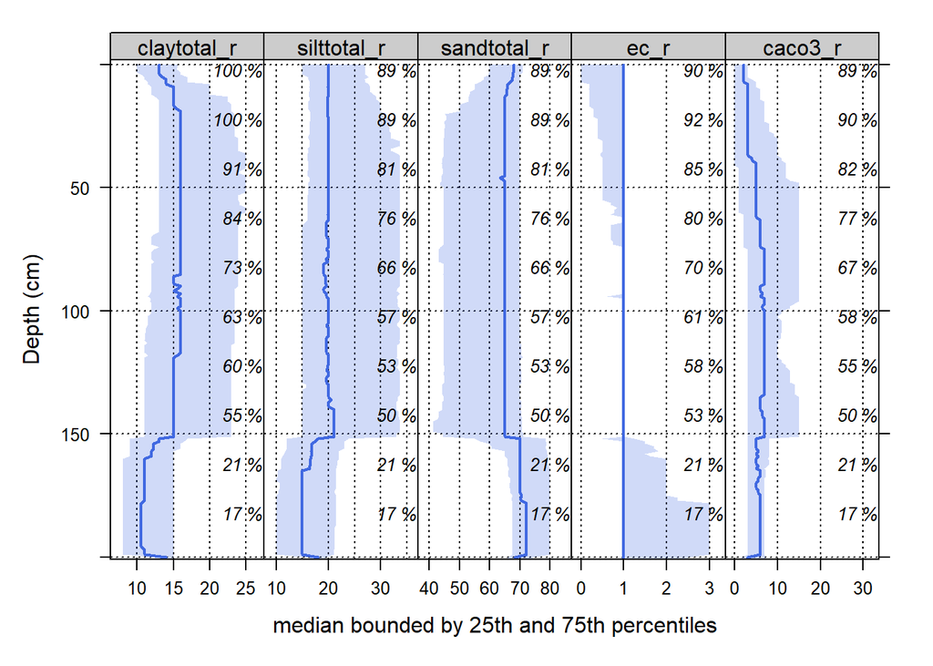

Figure 1: Soil properties by depth

# Ecological dynamics

## State and transition model development

### Reference state production indicators

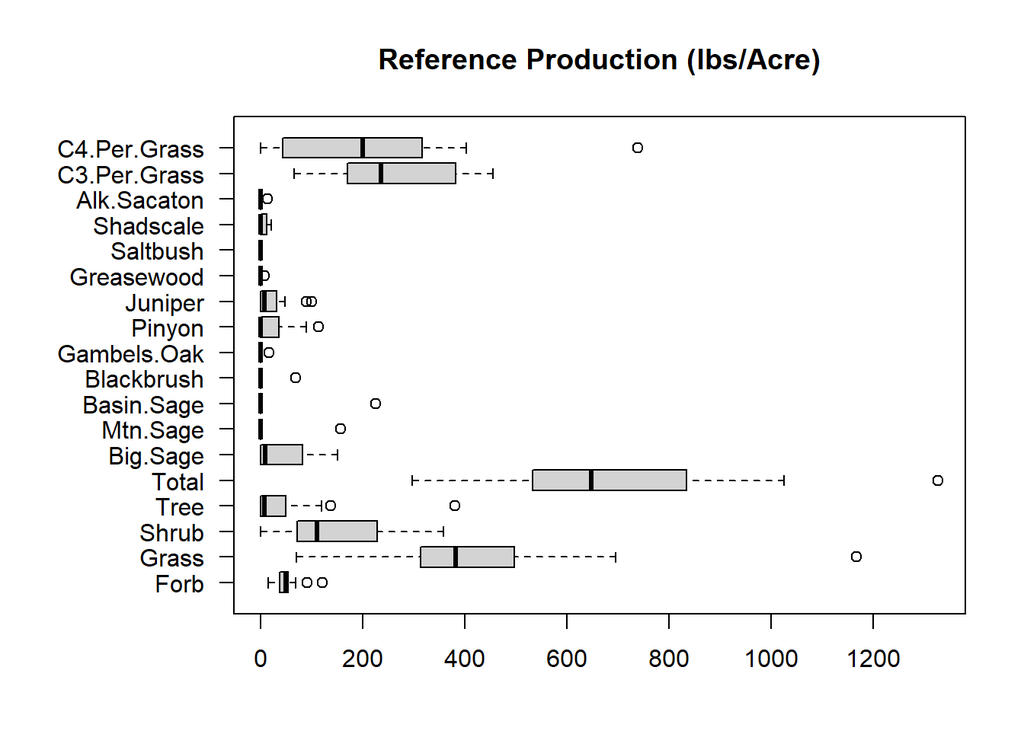

Figure 2: Reference state production by plant functional group

Table 6: Indicators used in ordination and clustering analysis to develop plant communities

| Indicator type | Indicator | Description |
| --- | --- | --- |
| Biotic | C3 native perennial grasses | Percent foliar cover of the functional group |
| Biotic | C3 introduced perennial grasses | Percent foliar cover of the functional group |
| Biotic | C4 native perennial grasses | Percent foliar cover of the functional group |
| Biotic | C4 introduced perennial grasses | Percent foliar cover of the functional group |
| Biotic | Native annual grasses | Percent foliar cover of the functional group |
| Biotic | Introduced annual grasses | Percent foliar cover of the functional group |
| Biotic | Native perennial forbs | Percent foliar cover of the functional group |
| Biotic | Introduced perennial forbs | Percent foliar cover of the functional group |
| Biotic | Native annual forbs | Percent foliar cover of the functional group |
| Biotic | Introduced annual forbs | Percent foliar cover of the functional group |
| Biotic | Artemisia tridentata (all subspecies) | Percent foliar cover of A. tridentata |
| Biotic | Lichens and mosses | Percent cover of lichens and mosses with no plant canopy above |
| Biotic | Shrub species | Percent foliar cover of each shrub species |
| Biotic | Sub-shrub species | Percent foliar cover of each sub-shrub species |
| Biotic | Tree species | Percent foliar cover of each tree species |
| Biotic | Opuntia spp. | Percent foliar cover of the genus Opuntia |
| Ecosystem structure | Bare soil | Percent cover of bare soil |
| Ecosystem structure | Litter | Percent cover of plant litter |
| Ecosystem structure | Ann. & peren. canopy gaps > 100 cm | Percent of transect lengths with canopy gaps > 100 cm, where annual and perennial plants stop a gap |
| Ecosystem structure | Ann. & peren. canopy gaps > 200 cm | Percent of transect lengths with canopy gaps > 200 cm, where annual and perennial plants stop a gap |

Field data from were collected by field crews with the Natural Resource Conservation Service’s (NRCS) National Resource Inventory (NRI) program, the Bureau of Land Management’s (BLM) Assessment, Inventory, and Monitoring (AIM) and Landscape Monitoring Framework (LMF) programs, and the Nationa Park Service’s (NPS) Inventory and Monitoring Northern Colorado Plateau Network (NCPN) program between 2004 and 2019. 802 plots were included for this ESG. Plant and soil cover were measured using line-point intercept and canopy gap methods (Herrick et al., 2017). Plot-level indicators (Table 6) were calculated using the terradactyl package in R (in development, McCord & Stauffer, 2020). When plots were sampled in multiple years, only the first sampling year was used in STM development. For plots that were missing annual & perennial gap data but had perennial-only gap data (primarily I&M-NCPN), annual & perennial gap values were imputed from perennial-only gaps and annual herbaceous cover using a linear model built from LMF and NRI plots that had both types of gap (r-squared of 0.86 and 0.85 for 100-cm and 200-cm gap predictions, respectively).

Plots were clustered into ecological communities using the FANNY fuzzy clustering algorithm (Kaufman and Rousseeuw, 1990) in the “cluster” R package (Maechler et al., 2021) with Bray-Curtis distance (“vegan” package; Oksanen et al., 2020). A suite of clustering indices were used to determine the most appropriate number of clusters and degree of fuzziness (i.e. membership exponent), including Calinski and Harabasz (1974), C-index (Hubert and Levin, 1976), cubic clustering criteria (Sarle, 1983), point-biserial correlation (Milligan 1980, 1981), Davies and Bouldin (1979), silhouette width (Rousseeuw 1987), and Dunn’s index (1974). Values between 1 and 12 possible clusters and 1.1 to 1.3 membership exponents were tested. The final clustering solution used 5 clusters with a membership exponent of 1.1.

The clustering results were visualized in ordination spaced, using non-metric multidimensional scaling (NMDS) with Bray-Curtis distance (“vegan” package in R). Based on testing ordination stress for 1 to 5 dimensions, ordination stress is acceptable with 3 dimensions, and stress reduction is minimal with additional dimensions. The stress for the ordination with 3 dimensions is 0.179.

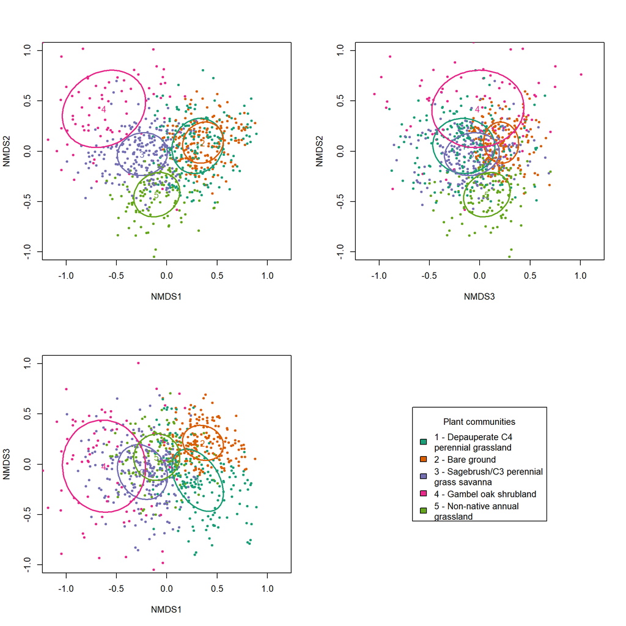

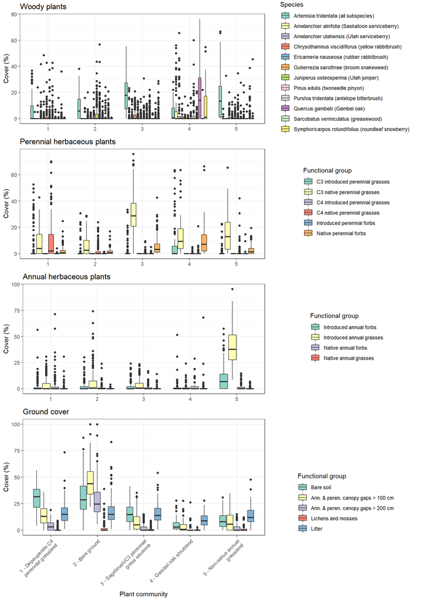

Figure 4: Plant cover by state

## State descriptive figures

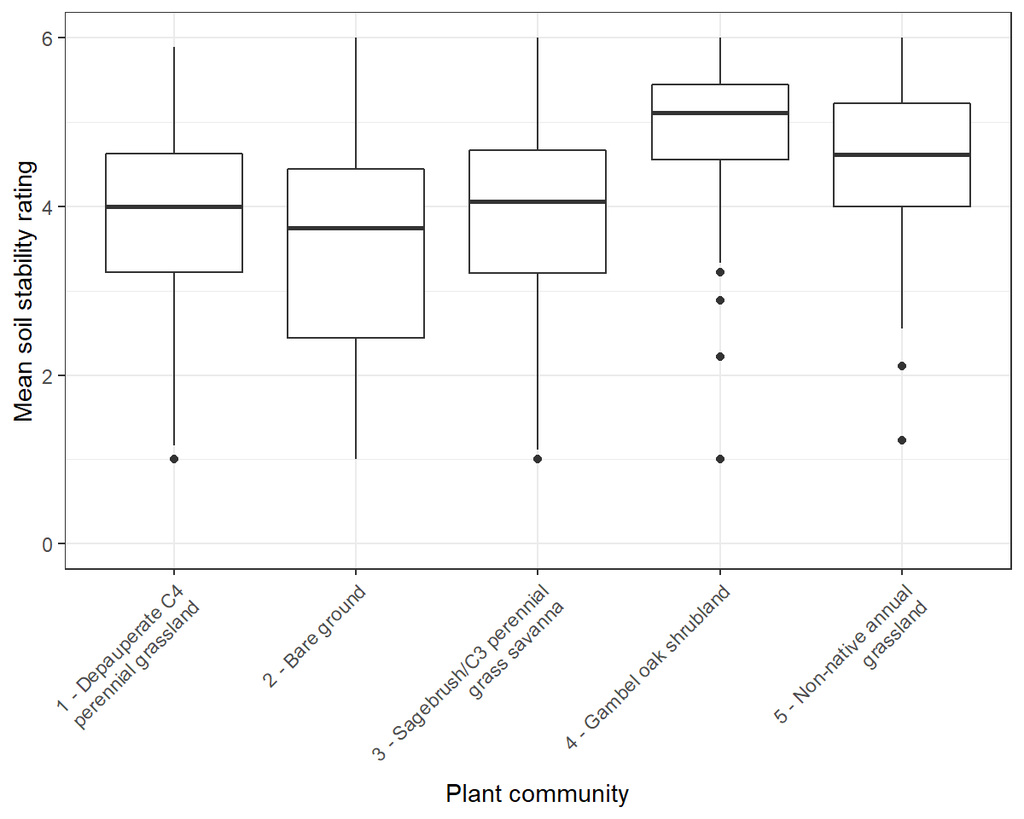

Figure 5: Soil stability by state

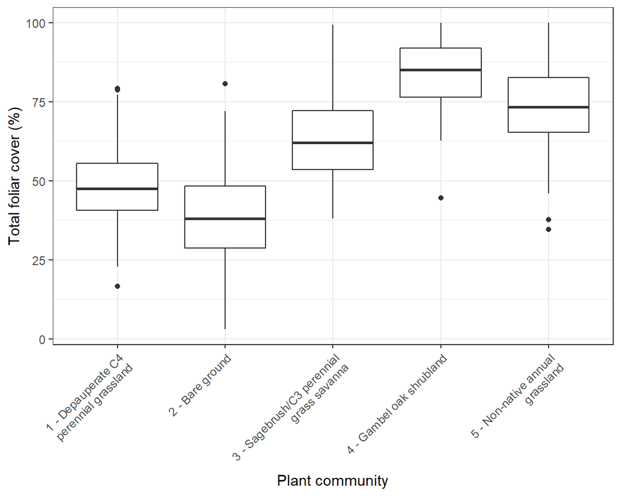

Figure 6: Total foliar cover by state

## Community 1.1

## Reference State: sagebrush/C3 perennial grass savanna

[output not shown]

[output not shown]

### Additional community tables

# Interpretations

## Other products

# Supporting information

## Contributors

- Travis Nauman
- Samuel Burch
- Anna Knight
- Mike Duniway

# Reference sheet

[Interpreting Indicators of Rangeland Health](https://wiki.landscapetoolbox.org/doku.php/field_methods:rangeland_health_assessment_i.e._indicators_of_rangeland_health) is a qualitative assessment protocol used to determine ecosystem condition based on benchmark characteristics described in the Reference Sheet. A suite of 17 (or more) indicators are typically considered in an assessment. The ecological site(s) representative of an assessment location must be known prior to applying the protocol and must be verified based on soils and climate. Current plant community cannot be used to identify the ecological site.

## Indicators

# Print options